# thesis_2

Yu He

2023-04-04

# load libraries

```r
library(tidyverse)
library(haven)
library(caret)
library(cluster)
library(nnet)
library(broom)
library(pROC)
```

```r
library(rpart.plot)
library(randomForest)
```

Variable list:

Demographic Factors: a. Age b. Sex c. Grade d. Race (race4)

Anthropometric Factors: a. Height - remove b. BMI c. BMI Percentile - removed d. Obesity Indicator (qnobese) - remove

Sexual Factors: a. Sexual Identity (sexed) - remove b. Birth Control Use (qnothhpl) c. Sexual Orientation (Q66) - remove

Food Allergy: a. Food Allergy (Qfoodallergy) - remove

Unintentional Injuries and Violence: a. Physical fights (Q17) b. Forced sexual activities (Q20) - remove c. Dating-related forced sexual activities (Q21) d. Bullying on school property (Q23) e. Suicidal thoughts (Q26)

Tobacco Use: a. Tried cigarette smoking (Q30)

Alcohol and Other Drug Use: a. Alcohol consumption (Q41) b. Marijuana use (Q47) c. Prescription pain medicine misuse (Q49) d. Cocaine use (Q50) e. Heroin use (Q52) f. Methamphetamine use (Q53) g. Needle use for injecting illegal drugs (Q56) - remove

Risky Sexual Behavior: a. Sexual intercourse (Q58) - remove b. Number of sexual partners (Q61) - remove c. Condom use (Q63) d. Sexual contact with different genders (Q65)

Cognitive and Health Factors: a. HIV testing (Q84) - remove b. Asthma diagnosis (Q87) c. School grades (Q89)

Outcome Variable: a. STI testing other than HIV (Q85)

# to do list: 1, remove the variabe with 0 level like age. 2. make q50, q52, and q53 into 2 level factors?. 3 remove q84?. 4. check difference between postreample and compare_resample function

# Step 1, data proparing

## data import and process, save the processed sas7dbat data into csv file to improve R runnig time. Only run one time.

```r
# set path
setwd("~/Desktop/CU Spring 2023/master thesis II2/CU_2023_yu")

# load state data a_m
#df_a_m = read_sas("./data/sadc_2019_state_a_m.sas7bdat") %>%
#  janitor::clean_names() %>%
#  select(sitename, year, age, sex, grade, race4, bmi, qnothhpl, q85,
#         q17, q21, q23, q26, q30, q41, q47, q49, q50, q52, q53, q63, q65, q87, q89
#         )

# save the data as a CSV file
# write.csv(df_a_m, "./data/df_a_m.csv", row.names = FALSE)

# load state data n_z
#df_n_z = read_sas("./data/sadc_2019_state_n_z.sas7bdat") %>%
#  janitor::clean_names() %>%
#  select(sitename, year, age, sex, grade, race4, bmi, qnothhpl, q85,
#         q17, q21, q23, q26, q30, q41, q47, q49, q50, q52, q53, q63, q65, q87, q89)

# save the data as a CSV file
#write.csv(df_n_z, "./data/df_n_z.csv", row.names = FALSE)

# load school district data
#df_district = read_sas("./data/sadc_2019_district.sas7bdat") %>%
#  janitor::clean_names() %>%
#   select(sitename, year, age, sex, grade, race4, bmi, qnothhpl, q85,
#        q17, q21, q23, q26, q30, q41, q47, q49, q50, q52, q53, q63, q65, q87, q89)

# save the data as a CSV file
#write.csv(df_district, "./data/df_district.csv", row.names = FALSE)
```

## import the processed data

```r
# load the processed  state data
df_part1 = read_csv("./data/df_a_m.csv")
df_part2 = read_csv("./data/df_n_z.csv")
# merge two state dataset
df_f_project = bind_rows(df_part1, df_part2)

# load the district dataset
df_district = read_csv("./data/df_district.csv")
```

## data cleaning

```r
# the state data
df_fit_state <-
  df_f_project %>%
  filter(year == 2019) %>%
  mutate(
  across(c("sex", "age", "grade", "race4", "qnothhpl"), as.factor),
  year = as.character(year)
  ) %>%
  mutate_at(vars(starts_with("q")), as.factor) %>%
  filter(q85 %in% c(1, 2, 3)) %>%
  na.omit()

# the school distrcit data
df_fit_district <-
  df_district %>%
  filter(year == 2019) %>%
    mutate(
  across(c("sex", "age", "grade", "race4", "qnothhpl"), as.factor),
  year = as.character(year)
  ) %>%
  mutate_at(vars(starts_with("q")), as.factor) %>%
  filter(q85 %in% c(1, 2, 3)) %>%
  na.omit()

df_fit_state %>%
  group_by(sitename) %>%
  summarize(
    n_obs = n()
  )
```

```
## # A tibble: 12 × 2
##    sitename            n_obs
##    <chr>               <int>
##  1 Alabama (AL)          308
##  2 Arkansas (AR)         304
##  3 Illinois (IL)         398
##  4 Iowa (IA)             235
##  5 Kentucky (KY)         313
##  6 Michigan (MI)         582
##  7 Mississippi (MS)      265
##  8 Nebraska (NE)         201
##  9 Oklahoma (OK)         348
## 10 Pennsylvania (PA)     440
## 11 South Carolina (SC)   126
## 12 West Virginia (WV)    284
```

```r
df_fit_district %>%
  group_by(sitename) %>%
  summarize(
    n_obs = n()
  )
```

```
## # A tibble: 15 × 2
##    sitename                     n_obs
##    <chr>                        <int>
##  1 Broward County, FL (FT)        168
##  2 Chicago, IL (CH)               157
##  3 Eaton Consortium, MI (EA)      129
##  4 Fort Worth, TX (FW)            237
##  5 Genesee Consortium, MI (GE)    166
##  6 Hillsborough County, FL (HL)   248
##  7 Los Angeles, CA (LO)           109
##  8 Newark, NJ (NW)                142
##  9 Orange County, FL (OL)         123
## 10 Palm Beach County, FL (PB)     305
## 11 Pasco County, FL (PS)          200
## 12 Philadelphia, PA (PH)          172
## 13 Portland, OR (PO)              213
## 14 San Francisco, CA (SF)         203
## 15 Shelby County, TN (ST)         160
```

```r
summary(df_fit_district)
```

```
##    sitename             year           age     sex      grade    race4
##  Length:2732        Length:2732        1:  0   1:1485   1: 276   1: 818
##  Class :character   Class :character   2:  0   2:1247   2: 610   2: 581
##  Mode  :character   Mode  :character   3:111            3: 825   3:1036
##                                        4:421            4:1021   4: 297
##                                        5:730
##                                        6:946
##                                        7:524
##       bmi        qnothhpl q85           q17       q21      q23      q26
##  Min.   :13.58   1: 735   1: 715   1      :1912   1: 240   1: 414   1: 651
##  1st Qu.:20.38   2:1997   2:1849   2      : 345   2:2299   2:2318   2:2081
##  Median :22.49            3: 168   3      : 296   3:  91
##  Mean   :23.64                     4      :  89   4:  55
##  3rd Qu.:25.72                     8      :  39   5:  17
##  Max.   :58.89                     5      :  28   6:  30
##                                    (Other):  23
##  q30      q41      q47      q49      q50      q52      q53      q63
##  1: 779   1:1535   1:1577   1:2197   1:2579   1:2703   1:2690   1:   0
##  2:1953   2: 593   2: 374   2: 230   2:  81   2:  12   2:  20   2:1512
##           3: 340   3: 293   3: 136   3:  48   3:   3   3:   5   3:1220
##           4: 154   4: 162   4:  77   4:   8   4:   6   4:   1
##           5:  83   5: 144   5:  30   5:   6   5:   1   5:   7
##           6:  15   6: 182   6:  62   6:  10   6:   7   6:   9
##           7:  12
##  q65      q87      q89
##  1:   0   1: 686   1: 874
##  2:1237   2:1940   2:1066
##  3:1226   3: 106   3: 520
##  4: 269            4: 104
##                    5:  50
##                    6:  14
##                    7: 104
```

```r
summary(df_fit_state)
```

```
##    sitename             year           age      sex      grade    race4
##  Length:3804        Length:3804        1:   0   1:2028   1: 501   1:2396
##  Class :character   Class :character   2:   5   2:1776   2: 848   2: 546
##  Mode  :character   Mode  :character   3: 130            3:1222   3: 550
##                                        4: 616            4:1233   4: 312
##                                        5:1012
##                                        6:1254
##                                        7: 787
##       bmi        qnothhpl q85           q17       q21      q23      q26
##  Min.   :13.25   1:1364   1: 770   1      :2686   1: 303   1: 843   1: 948
##  1st Qu.:20.62   2:2440   2:2822   2      : 503   2:3238   2:2961   2:2856
##  Median :22.89            3: 212   3      : 391   3: 112
##  Mean   :24.20                     4      :  96   4:  90
##  3rd Qu.:26.51                     8      :  60   5:  29
##  Max.   :54.40                     5      :  38   6:  32
##                                    (Other):  30
##  q30      q41      q47      q49      q50      q52      q53      q63
##  1:1636   1:2031   1:2473   1:3038   1:3608   1:3760   1:3737   1:   0
##  2:2168   2: 873   2: 427   2: 323   2: 101   2:  22   2:  27   2:2001
##           3: 445   3: 313   3: 196   3:  44   3:   3   3:  10   3:1803
##           4: 248   4: 193   4:  97   4:  24   4:   2   4:   7
##           5: 150   5: 145   5:  69   5:   6   5:   2   5:   3
##           6:  30   6: 253   6:  81   6:  21   6:  15   6:  20
##           7:  27
##  q65      q87      q89
##  1:   0   1: 946   1:1430
##  2:1744   2:2724   2:1396
##  3:1765   3: 134   3: 668
##  4: 295            4: 147
##                    5:  50
##                    6:  12
##                    7: 101
```

## check variables with 0 variance levels and re-create new variables for un-balanced variables

```r
# the modification for school district data
levels(df_fit_district$age)
```

```
## [1] "1" "2" "3" "4" "5" "6" "7"
```

```r
levels(df_fit_district$q63)
```

```
## [1] "1" "2" "3"
```

```r
levels(df_fit_district$q65)
```

```
## [1] "1" "2" "3" "4"
```

```r
# drop the level with 0
df_fit_district = df_fit_district %>%
  # Remove levels from the factor column
  filter(!(age %in% c("1", "2"))) %>%
  filter(q63 != 1) %>%
  filter(q65 != 1) %>%
  mutate(
  # Remove the unused levels from the factor column
     age = factor(age),
     q63 = factor(q63),
     q65 = factor(q65),
  # cover q50, q52, q53 to two level variables
  # 1 = 1, and 2 = the rest of observations
     q50 = ifelse(q50 == 1, 1, 2),
     q50 = factor(q50),
     q52 = ifelse(q52 == 1, 1, 2),
     q52 = factor(q52),
     q53 = ifelse(q53 == 1, 1, 2),
     q53 = factor(q53)
  )

summary(df_fit_district)
```

```
##    sitename             year           age     sex      grade    race4
##  Length:2732        Length:2732        3:111   1:1485   1: 276   1: 818
##  Class :character   Class :character   4:421   2:1247   2: 610   2: 581
##  Mode  :character   Mode  :character   5:730            3: 825   3:1036
##                                        6:946            4:1021   4: 297
##                                        7:524
##
##
##       bmi        qnothhpl q85           q17       q21      q23      q26
##  Min.   :13.58   1: 735   1: 715   1      :1912   1: 240   1: 414   1: 651
##  1st Qu.:20.38   2:1997   2:1849   2      : 345   2:2299   2:2318   2:2081
##  Median :22.49            3: 168   3      : 296   3:  91
##  Mean   :23.64                     4      :  89   4:  55
##  3rd Qu.:25.72                     8      :  39   5:  17
##  Max.   :58.89                     5      :  28   6:  30
##                                    (Other):  23
##  q30      q41      q47      q49      q50      q52      q53      q63
##  1: 779   1:1535   1:1577   1:2197   1:2579   1:2703   1:2690   2:1512
##  2:1953   2: 593   2: 374   2: 230   2: 153   2:  29   2:  42   3:1220
##           3: 340   3: 293   3: 136
##           4: 154   4: 162   4:  77
##           5:  83   5: 144   5:  30
##           6:  15   6: 182   6:  62
##           7:  12
##  q65      q87      q89
##  2:1237   1: 686   1: 874
##  3:1226   2:1940   2:1066
##  4: 269   3: 106   3: 520
##                    4: 104
##                    5:  50
##                    6:  14
##                    7: 104
```

```r
# the modification for state data
levels(df_fit_state$age)
```

```
## [1] "1" "2" "3" "4" "5" "6" "7"
```

```r
levels(df_fit_state$q63)
```

```
## [1] "1" "2" "3"
```

```r
levels(df_fit_state$q65)
```

```
## [1] "1" "2" "3" "4"
```

```r
# drop the level with 0
df_fit_state = df_fit_state %>%
  # Remove levels from the factor column
  filter(age != 1) %>%
  filter(q63 != 1) %>%
  filter(q65 != 1) %>%
  mutate(
  # Remove the unused levels from the factor column
     age = factor(age),
     q63 = factor(q63),
     q65 = factor(q65),
  # cover q50, q52, q53 to two level variables
  # 1 = 1, and 2 = the rest of observations
     q50 = ifelse(q50 == 1, 1, 2),
     q50 = factor(q50),
     q52 = ifelse(q52 == 1, 1, 2),
     q52 = factor(q52),
     q53 = ifelse(q53 == 1, 1, 2),
     q53 = factor(q53)
  )

summary(df_fit_state)
```

```
##    sitename             year           age      sex      grade    race4
##  Length:3804        Length:3804        2:   5   1:2028   1: 501   1:2396
##  Class :character   Class :character   3: 130   2:1776   2: 848   2: 546
##  Mode  :character   Mode  :character   4: 616            3:1222   3: 550
##                                        5:1012            4:1233   4: 312
##                                        6:1254
##                                        7: 787
##
##       bmi        qnothhpl q85           q17       q21      q23      q26
##  Min.   :13.25   1:1364   1: 770   1      :2686   1: 303   1: 843   1: 948
##  1st Qu.:20.62   2:2440   2:2822   2      : 503   2:3238   2:2961   2:2856
##  Median :22.89            3: 212   3      : 391   3: 112
##  Mean   :24.20                     4      :  96   4:  90
##  3rd Qu.:26.51                     8      :  60   5:  29
##  Max.   :54.40                     5      :  38   6:  32
##                                    (Other):  30
##  q30      q41      q47      q49      q50      q52      q53      q63
##  1:1636   1:2031   1:2473   1:3038   1:3608   1:3760   1:3737   2:2001
##  2:2168   2: 873   2: 427   2: 323   2: 196   2:  44   2:  67   3:1803
##           3: 445   3: 313   3: 196
##           4: 248   4: 193   4:  97
##           5: 150   5: 145   5:  69
##           6:  30   6: 253   6:  81
##           7:  27
##  q65      q87      q89
##  2:1744   1: 946   1:1430
##  3:1765   2:2724   2:1396
##  4: 295   3: 134   3: 668
##                    4: 147
##                    5:  50
##                    6:  12
##                    7: 101
```

```r
# Check for missing values
missing_vals_1 <- is.na(df_fit_district)

# Count the number of missing values in each column
colSums(missing_vals_1)
```

```
## sitename     year      age      sex    grade    race4      bmi qnothhpl
##        0        0        0        0        0        0        0        0
##      q85      q17      q21      q23      q26      q30      q41      q47
##        0        0        0        0        0        0        0        0
##      q49      q50      q52      q53      q63      q65      q87      q89
##        0        0        0        0        0        0        0        0
```

```r
# Check for missing values
missing_vals_2 <- is.na(df_fit_state)

# Count the number of missing values in each column
colSums(missing_vals_2)
```

```
## sitename     year      age      sex    grade    race4      bmi qnothhpl
##        0        0        0        0        0        0        0        0
##      q85      q17      q21      q23      q26      q30      q41      q47
##        0        0        0        0        0        0        0        0
##      q49      q50      q52      q53      q63      q65      q87      q89
##        0        0        0        0        0        0        0        0
```

# Step 2, fit the multinominal logistic regression

## first try to fit on the whole data, ignore clustered by sitename for now.

```r
df_state_lr <- df_fit_state %>%
  select(-year)

# Fit the model using the cleaned dataset
model <- multinom(q85 ~ ., data = df_state_lr)
summary_model = summary(model)

# Get a tidy version of the model output
tidy_model <- tidy(model)

# Set the significance level
alpha <- 0.05

# Find significant variables based on the p-value
significant_vars <- tidy_model$p.value < alpha

# Print the significant variables
significant_results <- tidy_model[significant_vars, ]
print(significant_results)
```

```
## # A tibble: 29 × 6
##    y.level term                       estimate std.error statistic   p.value
##    <chr>   <chr>                         <dbl>     <dbl>     <dbl>     <dbl>
##  1 2       (Intercept)                   6.88      0.368     18.7  4.11e- 78
##  2 2       sitenameMichigan (MI)        -0.468     0.189     -2.48 1.30e-  2
##  3 2       sitenameWest Virginia (WV)   -0.461     0.223     -2.06 3.91e-  2
##  4 2       age3                         -5.13      0.261    -19.6  8.09e- 86
##  5 2       age4                         -5.23      0.147    -35.7  4.90e-279
##  6 2       age5                         -5.27      0.140    -37.7  0
##  7 2       age6                         -5.67      0.157    -36.0  1.42e-284
##  8 2       age7                         -5.61      0.190    -29.5  1.96e-191
##  9 2       race42                       -0.750     0.140     -5.38 7.47e-  8
## 10 2       race43                       -0.361     0.133     -2.71 6.72e-  3
## # … with 19 more rows
```

## fit multinominal logistic regression for every disctrict

```r
# Define a function to fit the multinom model for each site
fit_multinom_for_site_d <- function(site, data) {
  df_site <- data %>%
    filter(sitename == site) %>%
    select(-sitename) %>%
    select(-year)

  # Fit the model using the cleaned dataset
  model <- multinom(q85 ~ ., data = df_site)

  summary_model <- summary(model)
  tidy_model <- tidy(model)

  # Set the significance level
  alpha <- 0.05

  # Find significant variables based on the p-value
  significant_vars <- tidy_model$p.value < alpha

  # Print the significant variables
  significant_results <- tidy_model[significant_vars, ]
  return(list(site = site, significant_results = significant_results))
}

# Get the unique site names from the dataset
unique_sites_d <- unique(df_fit_district$sitename)

# Fit the multinom model for each site
models_by_site <- lapply(unique_sites_d, fit_multinom_for_site_d, data = df_fit_district)
# Display the results
print(models_by_site)
```

```
## [[1]]
## [[1]]$site
## [1] "Chicago, IL (CH)"
##
## [[1]]$significant_results
## # A tibble: 78 × 6
##    y.level term        estimate std.error statistic p.value
##    <chr>   <chr>          <dbl>     <dbl>     <dbl>   <dbl>
##  1 2       (Intercept)   104.    2.48e+ 0   4.18e 1  0
##  2 2       age4         -100.    1.21e+ 0  -8.28e 1  0
##  3 2       age5         -101.    9.09e- 1  -1.11e 2  0
##  4 2       age6         -102.    9.17e- 1  -1.11e 2  0
##  5 2       age7         -100.    1.18e+ 0  -8.51e 1  0
##  6 2       qnothhpl2       1.88  7.74e- 1   2.43e 0  0.0151
##  7 <NA>    <NA>           NA    NA         NA       NA
##  8 2       q176          397.    5.76e-15   6.89e16  0
##  9 2       q177        -1102.    2.52e-14  -4.37e16  0
## 10 2       q178            8.58  1.25e- 5   6.88e 5  0
## # … with 68 more rows
##
##
## [[2]]
## [[2]]$site
## [1] "Eaton Consortium, MI (EA)"
##
## [[2]]$significant_results
## # A tibble: 80 × 6
##    y.level term  estimate  std.error   statistic p.value
##    <chr>   <chr>    <dbl>      <dbl>       <dbl>   <dbl>
##  1 2       q172     737.   6.42e- 20    1.15e 22       0
##  2 2       q175     230.   7.65e- 68    3.00e 69       0
##  3 <NA>    <NA>      NA   NA           NA             NA
##  4 <NA>    <NA>      NA   NA           NA             NA
##  5 2       q178   -1011.   3.67e-131   -2.75e133       0
##  6 2       q213    -750.   8.74e- 92   -8.59e 93       0
##  7 2       q214      17.5  0          Inf              0
##  8 2       q215     -98.3  0         -Inf              0
##  9 2       q216     -42.1  0         -Inf              0
## 10 2       q414     211.   8.81e- 47    2.39e 48       0
## # … with 70 more rows
```

[output cut: 258 more lines]

```
## [[15]]$significant_results
## # A tibble: 60 × 6
##    y.level term        estimate std.error statistic  p.value
##    <chr>   <chr>          <dbl>     <dbl>     <dbl>    <dbl>
##  1 2       (Intercept)    104.      27.4       3.78 1.54e- 4
##  2 2       age4           -45.2      6.49     -6.97 3.21e-12
##  3 2       age5           -36.4      6.01     -6.06 1.34e- 9
##  4 2       age6           -28.0      6.40     -4.37 1.26e- 5
##  5 2       age7           -27.0      6.70     -4.03 5.58e- 5
##  6 2       grade2         -47.7     19.7      -2.42 1.55e- 2
##  7 2       grade3         -58.5     19.1      -3.06 2.18e- 3
##  8 2       grade4         -72.8     19.6      -3.71 2.10e- 4
##  9 2       race42         -18.1      6.73     -2.69 7.05e- 3
## 10 2       race43         -10.2      4.71     -2.16 3.07e- 2
## # … with 50 more rows
```

## fit multinominal logistic regression for every state

```r
# Define a function to fit the multinom model for each site
fit_multinom_for_site_s <- function(site, data) {
  df_site <- data %>%
    filter(sitename == site) %>%
    select(-sitename) %>%
    select(-year)

  # Fit the model using the cleaned dataset
  model <- multinom(q85 ~ ., data = df_site)

  summary_model <- summary(model)
  tidy_model <- tidy(model)

  # Set the significance level
  alpha <- 0.05

  # Find significant variables based on the p-value
  significant_vars <- tidy_model$p.value < alpha

  # Print the significant variables
  significant_results <- tidy_model[significant_vars, ]
  return(list(site = site, significant_results = significant_results))
}

# Get the unique site names from the dataset
unique_sites_s <- unique(df_fit_state$sitename)

# Fit the multinom model for each site
models_by_site <- lapply(unique_sites_s, fit_multinom_for_site_s, data = df_fit_state)
# Display the results
print(models_by_site)
```

```
## [[1]]
## [[1]]$site
## [1] "Alabama (AL)"
##
## [[1]]$significant_results
## # A tibble: 48 × 6
##    y.level term        estimate std.error statistic    p.value
##    <chr>   <chr>          <dbl>     <dbl>     <dbl>      <dbl>
##  1 2       (Intercept)   21.1     2.40         8.76  1.87e- 18
##  2 2       age3         -24.0     1.47       -16.4   2.09e- 60
##  3 2       age4         -21.3     0.778      -27.4   2.01e-165
##  4 2       age5         -20.1     0.874      -23.0   1.93e-117
##  5 2       age6         -21.6     1.01       -21.4   2.04e-101
##  6 2       age7         -20.8     1.10       -19.0   1.52e- 80
##  7 2       qnothhpl2      1.07    0.471        2.28  2.26e-  2
##  8 2       q172           1.69    0.821        2.06  3.95e-  2
##  9 2       q176           0.747   0.00161    463.    0
## 10 <NA>    <NA>          NA      NA           NA    NA
## # … with 38 more rows
##
##
## [[2]]
## [[2]]$site
## [1] "Arkansas (AR)"
##
## [[2]]$significant_results
## # A tibble: 45 × 6
##    y.level term        estimate     std.error     statistic  p.value
##    <chr>   <chr>          <dbl>         <dbl>         <dbl>    <dbl>
##  1 2       (Intercept)     4.56 2.11                   2.16 0.0305
##  2 2       age3           -4.90 1.77                  -2.77 0.00556
##  3 2       age4           -2.02 0.901                 -2.24 0.0251
##  4 2       age6           -1.97 0.940                 -2.09 0.0366
##  5 2       qnothhpl2       1.69 0.478                  3.54 0.000406
##  6 2       q174           12.6  0.000196           64634.   0
##  7 2       q176           23.7  0.00000000399 5929652686.   0
##  8 2       q215            4.45 0.0000000262   169911531.   0
##  9 2       q302            1.20 0.528                  2.27 0.0230
## 10 2       q416           18.6  0.000145          127778.   0
## # … with 35 more rows
```

[output cut: 195 more lines]

```
## [[12]]$significant_results
## # A tibble: 43 × 6
##    y.level term      estimate std.error statistic p.value
##    <chr>   <chr>        <dbl>     <dbl>     <dbl>   <dbl>
##  1 2       grade2        1.87  7.90e- 1   2.36e 0 0.0182
##  2 2       race43       34.7   1.79e- 6   1.93e 7 0
##  3 2       qnothhpl2     1.60  5.13e- 1   3.11e 0 0.00186
##  4 2       q176         39.4   1.14e-11   3.45e12 0
##  5 2       q178         26.4   5.96e-10   4.43e10 0
##  6 2       q215         29.6   3.98e-12   7.45e12 0
##  7 2       q216         -9.81  7.68e- 5  -1.28e 5 0
##  8 2       q262         -1.24  5.66e- 1  -2.19e 0 0.0288
##  9 2       q417          8.47  2.19e-12   3.87e12 0
## 10 2       q495         26.1   1.26e+ 1   2.07e 0 0.0385
## # … with 33 more rows
```

# Step 3, fit the data with multinominal logistic regression, random forest, SVM, Elastic Net, ridge, lasso regression, and classification tree

```r
df_state_train <- df_fit_state %>%
  select(-year)

summary(df_state_train)
```

```
##    sitename         age      sex      grade    race4         bmi
##  Length:3804        2:   5   1:2028   1: 501   1:2396   Min.   :13.25
##  Class :character   3: 130   2:1776   2: 848   2: 546   1st Qu.:20.62
##  Mode  :character   4: 616            3:1222   3: 550   Median :22.89
##                     5:1012            4:1233   4: 312   Mean   :24.20
##                     6:1254                              3rd Qu.:26.51
##                     7: 787                              Max.   :54.40
##
##  qnothhpl q85           q17       q21      q23      q26      q30      q41
##  1:1364   1: 770   1      :2686   1: 303   1: 843   1: 948   1:1636   1:2031
##  2:2440   2:2822   2      : 503   2:3238   2:2961   2:2856   2:2168   2: 873
##           3: 212   3      : 391   3: 112                              3: 445
##                    4      :  96   4:  90                              4: 248
##                    8      :  60   5:  29                              5: 150
##                    5      :  38   6:  32                              6:  30
##                    (Other):  30                                       7:  27
##  q47      q49      q50      q52      q53      q63      q65      q87
##  1:2473   1:3038   1:3608   1:3760   1:3737   2:2001   2:1744   1: 946
##  2: 427   2: 323   2: 196   2:  44   2:  67   3:1803   3:1765   2:2724
##  3: 313   3: 196                                       4: 295   3: 134
##  4: 193   4:  97
##  5: 145   5:  69
##  6: 253   6:  81
##
##  q89
##  1:1430
##  2:1396
##  3: 668
##  4: 147
##  5:  50
##  6:  12
##  7: 101
```

## fit the multinominal logistic regression

```r
set.seed(123)
# 10-fold cross-validation
ctrl <- trainControl(method = "cv", number = 10, sampling = "up")

# Fit the model using the cleaned dataset
model_multinom <- train(q85 ~ .,
              data = df_state_train,
              method = "multinom",
              trControl = ctrl,
              preProcess = c("center", "scale"))
# check the results of the model
summary(model_multinom)
```

```
## Call:
## nnet::multinom(formula = .outcome ~ ., data = dat, decay = param$decay)
##
## Coefficients:
##   (Intercept) `sitenameArkansas (AR)` `sitenameIllinois (IL)`
## 2  0.05482568              0.05570404              -0.1137505
## 3 -0.03396734              0.08197197              -0.1360912
##   `sitenameIowa (IA)` `sitenameKentucky (KY)` `sitenameMichigan (MI)`
## 2         -0.06078546             -0.03335556              -0.1884593
## 3         -0.21302302              0.11569936              -0.1145338
##   `sitenameMississippi (MS)` `sitenameNebraska (NE)` `sitenameOklahoma (OK)`
## 2                  0.1137555              0.08362375             -0.01320778
## 3                  0.1252171             -0.02370411              0.05737184
##   `sitenamePennsylvania (PA)` `sitenameSouth Carolina (SC)`
## 2                 -0.02208769                   0.026996429
## 3                  0.17967979                   0.005977231
##   `sitenameWest Virginia (WV)`       age3       age4       age5       age6
## 2                  -0.12519123 -0.5136890 -1.0799582 -1.2842043 -1.5785473
## 3                  -0.04711865  0.1499898  0.6248885  0.6058198  0.3874844
##         age7      sex2      grade2       grade3      grade4     race42
## 2 -1.2581784 0.2294812  0.03320673  0.031909169 -0.04365167 -0.3148098
## 3  0.4292594 0.3017752 -0.09248410 -0.001013903 -0.34040713 -0.1260286
##         race43      race44         bmi qnothhpl2        q172        q173
## 2 -0.145190288 -0.06331463 -0.05709477 0.3838237 -0.02086303 -0.05846940
## 3  0.008283277 -0.09248364 -0.06132384 0.3306655 -0.13730507 -0.08708971
##          q174        q175         q176        q177        q178        q212
## 2 -0.03698021 -0.09242629  0.001532444 -0.05917927 -0.07341712 -0.01243523
## 3 -0.04653285 -0.05566914 -0.051472935 -0.26208462  0.05074495  0.02322658
##          q213       q214       q215         q216        q232       q262
## 2  0.02169173 -0.0222825  0.0616924  0.023003671  0.13261394 0.02198774
## 3 -0.03111643  0.1143372 -0.5319462 -0.005998302 -0.03079682 0.19552301
##          q302       q412         q413        q414       q415         q416
## 2  0.19628111 0.05432240  0.005299668  0.09553496 0.03162808  0.005179169
## 3 -0.03471106 0.08290254 -0.010934782 -0.12433863 0.10505699 -0.014552161
##          q417        q472         q473        q474        q475       q476
## 2 -0.02695318 -0.04627747 -0.009587799 -0.03536499 -0.04555841 -0.1050746
## 3 -0.05499784 -0.10815792 -0.079269176  0.02632117 -0.04892609 -0.1296884
##          q492        q493        q494        q495        q496        q502
## 2 -0.01680015 0.004370306 -0.06048689 -0.06717731 -0.05299269 -0.10919012
## 3 -0.11005230 0.222900267 -0.20441730  0.04339348  0.12600966 -0.05496359
```

[output cut: 35 more lines]

```
##         q415       q416       q417       q472       q473       q474       q475
## 2 0.03536066 0.03048612 0.03903117 0.02954704 0.02950006 0.03215277 0.03234343
## 3 0.03323708 0.02919383 0.03609569 0.03158145 0.03111054 0.03125408 0.03208263
##         q476       q492       q493       q494       q495       q496       q502
## 2 0.03406302 0.02877893 0.03470772 0.02813935 0.03447877 0.03895756 0.04093627
## 3 0.03357788 0.03158145 0.03070351 0.03661789 0.03000302 0.03180890 0.03786493
##         q522       q532       q633       q653       q654       q872       q873
## 2 0.03884546 0.04255872 0.03116641 0.07347334 0.04548171 0.03140391 0.03806659
## 3 0.03866495 0.03914101 0.03211041 0.07480962 0.04520932 0.03227247 0.03074180
##         q892       q893       q894       q895       q896       q897
## 2 0.03360889 0.03353270 0.03266224 0.02969491 0.03238529 0.03353442
## 3 0.03528581 0.03452815 0.03165936 0.03262597 0.03249850 0.03031274
##
## Residual Deviance: 16457.81
## AIC: 16741.81
```

```r
confusionMatrix(model_multinom)
```

```
## Cross-Validated (10 fold) Confusion Matrix
##
## (entries are percentual average cell counts across resamples)
##
##           Reference
## Prediction    1    2    3
##          1 10.2 18.9  1.7
##          2  5.6 34.7  1.8
##          3  4.5 20.6  2.1
##
##  Accuracy (average) : 0.469
```

```r
model_multinom$results
```

```
##   decay  Accuracy     Kappa AccuracySD    KappaSD
## 1 0e+00 0.4660968 0.1300793 0.01530303 0.02703492
## 2 1e-04 0.4679369 0.1282634 0.02283198 0.03430897
## 3 1e-01 0.4689985 0.1301229 0.02516628 0.03010043
```

```r
varImp(model_multinom)
```

```
## multinom variable importance
##
##   only 20 most important variables shown (out of 70)
##
##                            Overall
## age6                        100.00
## age5                         96.10
## age4                         86.60
## age7                         85.71
## qnothhpl2                    35.81
## age3                         33.21
## q215                         29.61
## sex2                         26.41
## race42                       21.78
## grade4                       18.86
## q653                         18.56
## q177                         15.64
## q873                         15.31
## `sitenameMichigan (MI)`      14.71
## `sitenameIowa (IA)`          13.21
## q654                         13.08
## q872                         12.88
## q494                         12.75
## `sitenameIllinois (IL)`      11.98
## `sitenameMississippi (MS)`   11.42
```

```r
multinom_outcome <- predict(model_multinom, df_state_train, type = "raw")

# Create confusion matrix
multinom_evaluation <- confusionMatrix(multinom_outcome, df_state_train$q85)
multinom_evaluation
```

```
## Confusion Matrix and Statistics
##
##           Reference
## Prediction    1    2    3
##          1  424  715   48
##          2  194 1359   53
##          3  152  748  111
##
## Overall Statistics
##
##                Accuracy : 0.4979
##                  95% CI : (0.4819, 0.5139)
##     No Information Rate : 0.7419
##     P-Value [Acc > NIR] : 1
##
##                   Kappa : 0.1753
##
##  Mcnemar's Test P-Value : <2e-16
##
## Statistics by Class:
##
##                      Class: 1 Class: 2 Class: 3
## Sensitivity            0.5506   0.4816  0.52358
## Specificity            0.7485   0.7485  0.74944
## Pos Pred Value         0.3572   0.8462  0.10979
## Neg Pred Value         0.8678   0.3344  0.96384
## Prevalence             0.2024   0.7419  0.05573
## Detection Rate         0.1115   0.3573  0.02918
## Detection Prevalence   0.3120   0.4222  0.26577
## Balanced Accuracy      0.6496   0.6150  0.63651
```

## fit the random forest

```r
#ntree = 100
#set.seed(123)
# Setting 5-fold cross-validation for fast demonstration.
#control_settings <- trainControl(method = "cv", number = 10, sampling = "up")

# Trying three different values of mtry
#mtry_vals_rf <- c(ncol(df_state_train)-1,
#                 sqrt(ncol(df_state_train)-1),
#                  0.5*ncol(df_state_train)-1)
#mtry_grid_rf<- expand.grid(.mtry = round(mtry_vals_rf))

#model_rf <- train(q85 ~., data = df_state_train,
#                  method = "rf", metric = "Accuracy",
#                  preProc=c("center", "scale"),
#                  tuneGrid = mtry_grid_rf,
#                  trControl = control_settings, ntree = 100)

#confusionMatrix(model_rf)
#model_rf$results
#model_rf$bestTune
#model_rf$finalModel

#varImp(model_rf)
```

```r
# ntree = 200
#set.seed(123)
# Setting 5-fold cross-validation for fast demonstration.
#control_settings <- trainControl(method = "cv", number = 10, sampling = "up")

# Trying three different values of mtry
#mtry_vals_rf <- c(ncol(df_state_train)-1,
#                  sqrt(ncol(df_state_train)-1),
#                  0.5*ncol(df_state_train)-1)
#mtry_grid_rf<- expand.grid(.mtry = round(mtry_vals_rf))

#model_rf <- train(q85 ~., data = df_state_train,
#                  method = "rf", metric = "Accuracy",
#                  preProc=c("center", "scale"),
#                  tuneGrid = mtry_grid_rf,
#                  trControl = control_settings, ntree = 200)

#confusionMatrix(model_rf)
#model_rf$results
#model_rf$bestTune
#model_rf$finalModel

#varImp(model_rf)

#rf_outcome <- predict(model_rf, df_state_train, type = "raw")
#confusionMatrix(rf_outcome, df_state_train$q85)
```

```r
 ntree = 400
set.seed(123)
# Setting 5-fold cross-validation for fast demonstration.
control_settings <- trainControl(method = "cv", number = 10, sampling = "up")

# Trying three different values of mtry
mtry_vals_rf <- c(ncol(df_state_train)-1,
                  sqrt(ncol(df_state_train)-1),
                  0.5*ncol(df_state_train)-1)
mtry_grid_rf<- expand.grid(.mtry = round(mtry_vals_rf))

model_rf <- train(q85 ~., data = df_state_train,
                  method = "rf", metric = "Accuracy",
                  preProc=c("center", "scale"),
                  tuneGrid = mtry_grid_rf,
                  trControl = control_settings, ntree = 400)

confusionMatrix(model_rf)
```

```
## Cross-Validated (10 fold) Confusion Matrix
##
## (entries are percentual average cell counts across resamples)
##
##           Reference
## Prediction    1    2    3
##          1  4.3  5.7  0.6
##          2 15.8 67.8  5.0
##          3  0.2  0.7  0.0
##
##  Accuracy (average) : 0.7219
```

```r
model_rf$results
```

```
##   mtry  Accuracy     Kappa AccuracySD    KappaSD
## 1    5 0.6905919 0.1670279 0.02067660 0.06209390
## 2   10 0.7202970 0.1409010 0.01591824 0.04386356
## 3   22 0.7218739 0.1329009 0.01344936 0.04716696
```

```r
model_rf$bestTune
```

```
##   mtry
## 3   22
```

```r
model_rf$finalModel
```

```
##
## Call:
##  randomForest(x = x, y = y, ntree = 400, mtry = param$mtry)
##                Type of random forest: classification
##                      Number of trees: 400
## No. of variables tried at each split: 22
##
##         OOB estimate of  error rate: 3.47%
## Confusion matrix:
##      1    2    3 class.error
## 1 2789   32    1  0.01169383
## 2  236 2561   25  0.09248760
## 3    0    0 2822  0.00000000
```

```r
varImp(model_rf)
```

```
## rf variable importance
##
##   only 20 most important variables shown (out of 70)
##
##                           Overall
## bmi                       100.000
## q892                       15.176
## q302                       14.534
## q633                       14.476
## qnothhpl2                  13.578
## q412                       12.876
## q872                       12.511
## q232                       11.509
## q893                       11.412
## q262                       11.186
## race42                     11.161
## sitenameMichigan (MI)      10.657
## age6                       10.325
## race43                      9.871
## sex2                        9.727
## sitenamePennsylvania (PA)   9.483
## q172                        9.214
## grade3                      9.026
## q472                        9.011
## q212                        8.814
```

```r
rf_outcome <- predict(model_rf, df_state_train, type = "raw")
confusionMatrix(rf_outcome, df_state_train$q85)
```

```
## Confusion Matrix and Statistics
##
##           Reference
## Prediction    1    2    3
##          1  770    1    0
##          2    0 2820    0
##          3    0    1  212
##
## Overall Statistics
##
##                Accuracy : 0.9995
##                  95% CI : (0.9981, 0.9999)
##     No Information Rate : 0.7419
##     P-Value [Acc > NIR] : < 2.2e-16
##
##                   Kappa : 0.9987
##
##  Mcnemar's Test P-Value : NA
##
## Statistics by Class:
##
##                      Class: 1 Class: 2 Class: 3
## Sensitivity            1.0000   0.9993  1.00000
## Specificity            0.9997   1.0000  0.99972
## Pos Pred Value         0.9987   1.0000  0.99531
## Neg Pred Value         1.0000   0.9980  1.00000
## Prevalence             0.2024   0.7419  0.05573
## Detection Rate         0.2024   0.7413  0.05573
## Detection Prevalence   0.2027   0.7413  0.05599
## Balanced Accuracy      0.9998   0.9996  0.99986
```

## fit the SVM

```r
set.seed(123)

# Specify training control
train_control_svc <- trainControl(method = "cv", number = 10, sampling = "up")

# Create tuning grid
grid_svc <- expand.grid(C = seq(0.001, 2, length = 30))

# Train model with cross-validation and tuning
# Incorporate different values for cost (C)
model_svc <- train(q85 ~ .,
                   data = df_state_train,
                   method = "svmLinear",
                   trControl = train_control_svc,
                   preProcess = c("center", "scale"),
                   tuneGrid = grid_svc)

model_svc$bestTune
```

```
##            C
## 13 0.8281724
```

```r
model_svc$results
```

```
##             C  Accuracy     Kappa AccuracySD    KappaSD
## 1  0.00100000 0.4545586 0.1312797 0.03660747 0.03090965
## 2  0.06993103 0.4474430 0.1238304 0.02669759 0.02597720
## 3  0.13886207 0.4377248 0.1115284 0.04123796 0.03793497
## 4  0.20779310 0.4484984 0.1262924 0.03188411 0.03104868
## 5  0.27672414 0.4453502 0.1182483 0.03051715 0.03020356
## 6  0.34565517 0.4492996 0.1245613 0.03738131 0.03609866
## 7  0.41458621 0.4427207 0.1126131 0.03046540 0.03534170
## 8  0.48351724 0.4456154 0.1192809 0.03162877 0.03308538
## 9  0.55244828 0.4492879 0.1241014 0.03900766 0.03748177
## 10 0.62137931 0.4537505 0.1196369 0.01909364 0.02958346
## 11 0.69031034 0.4450808 0.1170796 0.03608093 0.03161414
## 12 0.75924138 0.4513952 0.1247527 0.03505514 0.03077318
## 13 0.82817241 0.4595462 0.1293140 0.03178794 0.02910441
## 14 0.89710345 0.4421895 0.1178227 0.03182813 0.03797768
```

[output cut: 16 more lines]

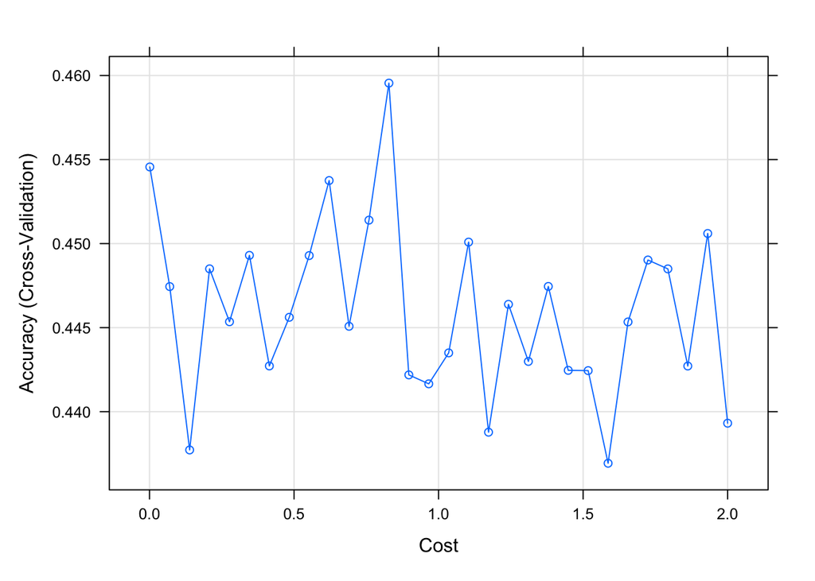

```r
#Visualize accuracy versus values of C
plot(model_svc)
```

```r
#Obtain metrics of accuracy from training
confusionMatrix(model_svc)
```

```
## Cross-Validated (10 fold) Confusion Matrix
##
## (entries are percentual average cell counts across resamples)
##
##           Reference
## Prediction    1    2    3
##          1 10.9 19.8  1.7
##          2  4.8 33.3  2.1
##          3  4.6 21.0  1.8
##
##  Accuracy (average) : 0.4595
```

```r
#See information about final model
model_svc$finalModel
```

```
## Support Vector Machine object of class "ksvm"
##
## SV type: C-svc  (classification)
##  parameter : cost C = 0.828172413793104
##
## Linear (vanilla) kernel function.
##
## Number of Support Vectors : 7566
##
## Objective Function Value : -3477.294 -3111.878 -3563.367
## Training error : 0.472478
```

```r
# varImp(model_svc)

svm_outcome <- predict(model_svc, df_state_train, type = "raw")
confusionMatrix(svm_outcome, df_state_train$q85)
```

```
## Confusion Matrix and Statistics
##
##           Reference
## Prediction    1    2    3
##          1  436  742   51
##          2  175 1286   46
##          3  159  794  115
##
## Overall Statistics
##
##                Accuracy : 0.4829
##                  95% CI : (0.4669, 0.4989)
##     No Information Rate : 0.7419
##     P-Value [Acc > NIR] : 1
##
##                   Kappa : 0.1727
##
##  Mcnemar's Test P-Value : <2e-16
##
## Statistics by Class:
##
##                      Class: 1 Class: 2 Class: 3
## Sensitivity            0.5662   0.4557  0.54245
## Specificity            0.7386   0.7749  0.73469
## Pos Pred Value         0.3548   0.8534  0.10768
## Neg Pred Value         0.8703   0.3313  0.96455
## Prevalence             0.2024   0.7419  0.05573
## Detection Rate         0.1146   0.3381  0.03023
## Detection Prevalence   0.3231   0.3962  0.28076
## Balanced Accuracy      0.6524   0.6153  0.63857
```

## fit the lasso regression

```r
set.seed(123)
#Create grid to search lambda
lambda <- 10^seq(-3,3, length = 100)

# Specify training control
train_control_lasso <- trainControl(method = "cv", number = 10)

model_lasso = train(q85 ~.,
                    df_state_train,
                    method = "glmnet",
                    trControl = train_control_lasso,
                    tuneGrid = expand.grid(alpha = 1, lambda = lambda))

summary(model_lasso)
```

```
##             Length Class      Mode
## a0          195    -none-     numeric
## beta          3    -none-     list
## dfmat       195    -none-     numeric
## df           65    -none-     numeric
## dim           2    -none-     numeric
## lambda       65    -none-     numeric
## dev.ratio    65    -none-     numeric
## nulldev       1    -none-     numeric
## npasses       1    -none-     numeric
## jerr          1    -none-     numeric
## offset        1    -none-     logical
## classnames    3    -none-     character
## grouped       1    -none-     logical
## call          5    -none-     call
## nobs          1    -none-     numeric
## lambdaOpt     1    -none-     numeric
## xNames       70    -none-     character
## problemType   1    -none-     character
## tuneValue     2    data.frame list
## obsLevels     3    -none-     character
## param         0    -none-     list
```

```r
model_lasso$bestTune
```

```
##    alpha      lambda
## 11     1 0.004037017
```

```r
model_lasso$results
```

```
##     alpha       lambda  Accuracy       Kappa   AccuracySD     KappaSD
## 1       1 1.000000e-03 0.7426406 0.090226439 0.0124550446 0.038698252
## 2       1 1.149757e-03 0.7423774 0.087869374 0.0119296081 0.037713003
## 3       1 1.321941e-03 0.7423767 0.086931015 0.0118157831 0.037332748
## 4       1 1.519911e-03 0.7418518 0.081123510 0.0113827816 0.039268361
## 5       1 1.747528e-03 0.7418525 0.079283640 0.0107420419 0.036751280
## 6       1 2.009233e-03 0.7415900 0.076899512 0.0106755281 0.038085618
## 7       1 2.310130e-03 0.7423774 0.077821771 0.0103413852 0.037749131
## 8       1 2.656088e-03 0.7426399 0.075459971 0.0092070110 0.034720051
## 9       1 3.053856e-03 0.7429044 0.072114805 0.0091837218 0.036493369
## 10      1 3.511192e-03 0.7434314 0.068448494 0.0087478878 0.032652489
## 11      1 4.037017e-03 0.7436932 0.064171249 0.0085217494 0.029525998
## 12      1 4.641589e-03 0.7434300 0.061717994 0.0088774852 0.031629524
## 13      1 5.336699e-03 0.7436925 0.059194870 0.0081761611 0.031811489
## 14      1 6.135907e-03 0.7436925 0.053769598 0.0078887772 0.031678028
```

[output cut: 86 more lines]

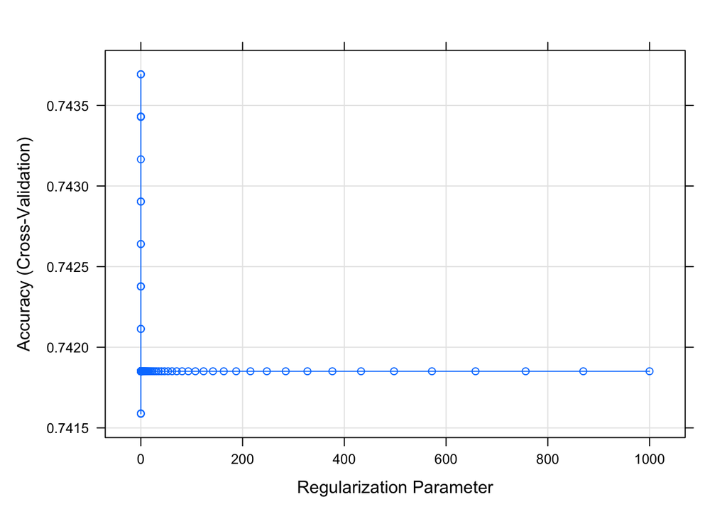

```r
#Visualize accuracy versus values of C
plot(model_lasso)
```

```r
#Obtain metrics of accuracy from training
confusionMatrix(model_lasso)
```

```
## Cross-Validated (10 fold) Confusion Matrix
##
## (entries are percentual average cell counts across resamples)
##
##           Reference
## Prediction    1    2    3
##          1  1.5  1.3  0.2
##          2 18.8 72.9  5.4
##          3  0.0  0.0  0.0
##
##  Accuracy (average) : 0.7437
```

```r
varImp(model_lasso)
```

```
## glmnet variable importance
##
##   variables are sorted by maximum importance across the classes
##   only 20 most important variables shown (out of 70)
##
##                              1        2       3
## q215                      0.00 100.0000  0.0000
## qnothhpl2                80.70   0.0000  0.0000
## q177                     73.59   0.0000  0.0000
## q873                      0.00  48.0369 57.4570
## sex2                     49.48   0.0000  0.9846
## q532                     49.33  10.8296  0.0000
## q494                     48.41   0.0000 13.8738
## q496                      0.00  48.3537 10.3454
## q493                      0.00  10.3720 43.9308
## q654                     43.40   0.6297  0.0000
## q495                      0.00  18.4179 42.7671
## race42                   41.46  33.5093  0.0000
## q897                     10.40  41.0711  0.0000
## q302                      0.00  41.0252  0.0000
## grade4                   10.13   0.0000 39.3108
## q476                     35.41   1.8399  0.0000
## sitenameIllinois (IL)    33.35   0.0000  0.0000
## q896                     33.32   0.0000  0.0000
## sitenameMississippi (MS) 33.08   1.7757  0.0000
## q894                      4.07  32.4481  0.0000
```

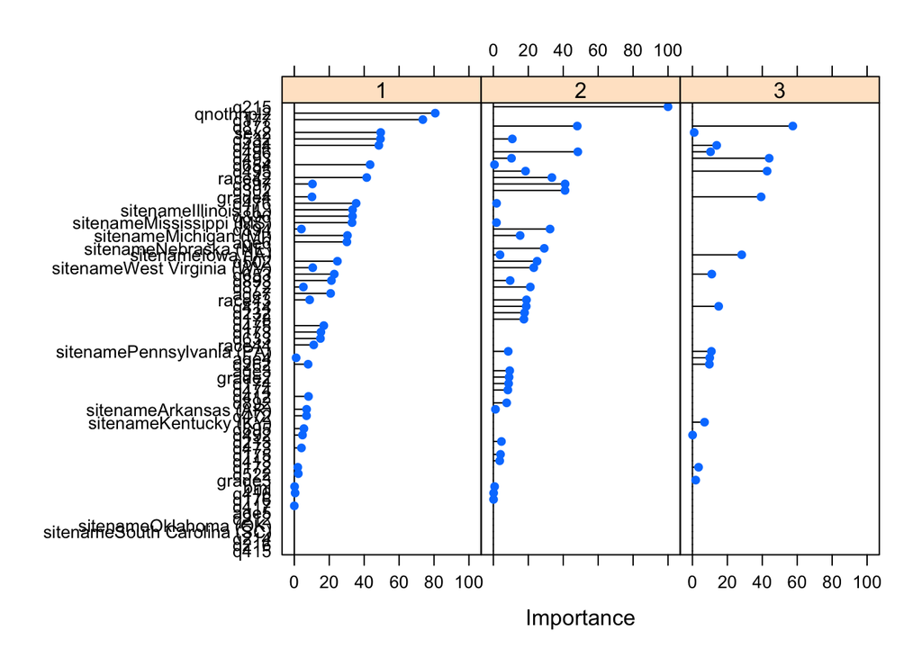

```r
plot(varImp(model_lasso))
```

```r
lasso_outcome <- predict(model_lasso, df_state_train, type = "raw")
confusionMatrix(lasso_outcome, df_state_train$q85)
```

```
## Confusion Matrix and Statistics
##
##           Reference
## Prediction    1    2    3
##          1   67   40    5
##          2  703 2782  207
##          3    0    0    0
##
## Overall Statistics
##
##                Accuracy : 0.7489
##                  95% CI : (0.7348, 0.7627)
##     No Information Rate : 0.7419
##     P-Value [Acc > NIR] : 0.1631
##
##                   Kappa : 0.0839
##
##  Mcnemar's Test P-Value : <2e-16
##
## Statistics by Class:
##
##                      Class: 1 Class: 2 Class: 3
## Sensitivity           0.08701  0.98583  0.00000
## Specificity           0.98517  0.07332  1.00000
## Pos Pred Value        0.59821  0.75352      NaN
## Neg Pred Value        0.80959  0.64286  0.94427
## Prevalence            0.20242  0.74185  0.05573
## Detection Rate        0.01761  0.73134  0.00000
## Detection Prevalence  0.02944  0.97056  0.00000
## Balanced Accuracy     0.53609  0.52957  0.50000
```

## fit the ridge regression

```r
set.seed(123)
#Create grid to search lambda
lambda <- 10^seq(-3,3, length = 100)

# Specify training control
train_control_ridge <- trainControl(method = "cv", number = 10)

model_ridge = train(q85 ~.,
                    df_state_train,
                    method = "glmnet",
                    trControl = train_control_ridge,
                    tuneGrid = expand.grid(alpha = 0, lambda = lambda))

summary(model_ridge)
```

```
##             Length Class      Mode
## a0          300    -none-     numeric
## beta          3    -none-     list
## dfmat       300    -none-     numeric
## df          100    -none-     numeric
## dim           2    -none-     numeric
## lambda      100    -none-     numeric
## dev.ratio   100    -none-     numeric
## nulldev       1    -none-     numeric
## npasses       1    -none-     numeric
## jerr          1    -none-     numeric
## offset        1    -none-     logical
## classnames    3    -none-     character
## grouped       1    -none-     logical
## call          5    -none-     call
## nobs          1    -none-     numeric
## lambdaOpt     1    -none-     numeric
## xNames       70    -none-     character
## problemType   1    -none-     character
## tuneValue     2    data.frame list
## obsLevels     3    -none-     character
## param         0    -none-     list
```

```r
model_ridge$bestTune
```

```
##    alpha     lambda
## 31     0 0.06579332
```

```r
model_ridge$results
```

```
##     alpha       lambda  Accuracy         Kappa   AccuracySD     KappaSD
## 1       0 1.000000e-03 0.7429037  0.0953032511 0.0109621434 0.033449824
## 2       0 1.149757e-03 0.7429037  0.0953032511 0.0109621434 0.033449824
## 3       0 1.321941e-03 0.7429037  0.0953032511 0.0109621434 0.033449824
## 4       0 1.519911e-03 0.7429037  0.0953032511 0.0109621434 0.033449824
## 5       0 1.747528e-03 0.7429037  0.0953032511 0.0109621434 0.033449824
## 6       0 2.009233e-03 0.7429037  0.0953032511 0.0109621434 0.033449824
## 7       0 2.310130e-03 0.7429037  0.0953032511 0.0109621434 0.033449824
## 8       0 2.656088e-03 0.7429037  0.0953032511 0.0109621434 0.033449824
## 9       0 3.053856e-03 0.7429037  0.0953032511 0.0109621434 0.033449824
## 10      0 3.511192e-03 0.7429037  0.0953032511 0.0109621434 0.033449824
## 11      0 4.037017e-03 0.7429037  0.0953032511 0.0109621434 0.033449824
## 12      0 4.641589e-03 0.7429037  0.0953032511 0.0109621434 0.033449824
## 13      0 5.336699e-03 0.7429037  0.0953032511 0.0109621434 0.033449824
## 14      0 6.135907e-03 0.7429037  0.0953032511 0.0109621434 0.033449824
```

[output cut: 86 more lines]

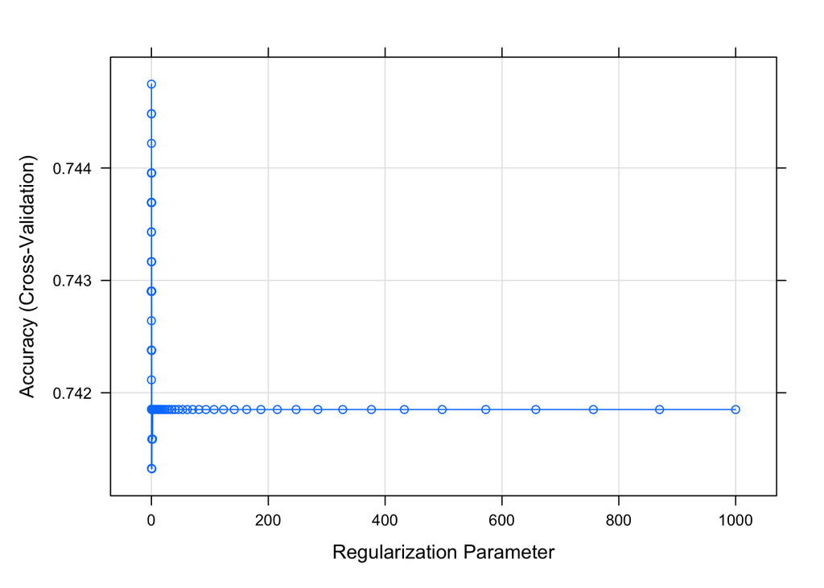

```r
#Visualize accuracy versus values of C
plot(model_ridge)
```

```r
#Obtain metrics of accuracy from training
confusionMatrix(model_ridge)
```

```
## Cross-Validated (10 fold) Confusion Matrix
##
## (entries are percentual average cell counts across resamples)
##
##           Reference
## Prediction    1    2    3
##          1  1.7  1.4  0.2
##          2 18.5 72.8  5.4
##          3  0.0  0.0  0.0
##
##  Accuracy (average) : 0.7447
```

```r
varImp(model_ridge)
```

```
## glmnet variable importance
##
##   variables are sorted by maximum importance across the classes
##   only 20 most important variables shown (out of 70)
##
##                                1      2       3
## q177                     100.000 17.597 82.2934
## q215                      36.910 96.082 59.0630
## q896                      69.489 34.639 34.7403
## q873                       4.364 62.929 67.4031
## qnothhpl2                 54.476 36.100 18.2668
## q494                      53.310  7.464 45.7358
## q495                      10.611 41.160 51.8804
## q496                       9.490 50.802 41.2028
## race42                    42.440 42.849  0.2992
## q897                      31.126 42.820 11.5845
## q493                      12.127 30.372 42.6085
## q532                      41.418 34.426  6.8830
## q654                      35.830 28.744  6.9763
## sex2                      35.769 14.880 20.7795
## q894                      22.713 33.238 10.4156
## q476                      32.524 22.736  9.6775
## sitenameIowa (IA)          8.135 23.273 31.5180
## sitenameMississippi (MS)  30.766 22.135  8.5219
## q502                      30.389 28.559  1.7203
## q653                      30.093 10.724 19.2602
```

```r
ridge_outcome <- predict(model_ridge, df_state_train, type = "raw")
confusionMatrix(ridge_outcome, df_state_train$q85)
```

```
## Confusion Matrix and Statistics
##
##           Reference
## Prediction    1    2    3
##          1   75   40    5
##          2  695 2782  207
##          3    0    0    0
##
## Overall Statistics
##
##                Accuracy : 0.7511
##                  95% CI : (0.737, 0.7647)
##     No Information Rate : 0.7419
##     P-Value [Acc > NIR] : 0.1002
##
##                   Kappa : 0.0953
##
##  Mcnemar's Test P-Value : <2e-16
##
## Statistics by Class:
##
##                      Class: 1 Class: 2 Class: 3
## Sensitivity           0.09740  0.98583  0.00000
## Specificity           0.98517  0.08147  1.00000
## Pos Pred Value        0.62500  0.75516      NaN
## Neg Pred Value        0.81135  0.66667  0.94427
## Prevalence            0.20242  0.74185  0.05573
## Detection Rate        0.01972  0.73134  0.00000
## Detection Prevalence  0.03155  0.96845  0.00000
## Balanced Accuracy     0.54129  0.53365  0.50000
```

## fit the Elastic Net method

```r
# model 2, chooses alpha and lambda via cross-validation using all of the features - Elastic Net method
set.seed(123)

# Construct k-folds in your data
trcontrol = trainControl(method = "cv", number = 10)

# model 2 fit
model_elastic_net <- train(q85 ~.,
                     data = df_state_train,
                     method = "glmnet",
                     trControl = trcontrol,
                     preProc=c("center", "scale"),
                     tuneLength = 10, metric = "Accuracy"
  )

# Print the values of alpha and lambda that gave best prediction
model_elastic_net$bestTune
```

```
##    alpha     lambda
## 19   0.2 0.02257654
```

```r
# Print all of the options examined
model_elastic_net$results
```

```
##     alpha       lambda  Accuracy       Kappa   AccuracySD     KappaSD
## 1     0.1 2.783342e-05 0.7429037 0.098081618 0.0111707382 0.031991249
## 2     0.1 6.429880e-05 0.7429037 0.098081618 0.0111707382 0.031991249
## 3     0.1 1.485386e-04 0.7429037 0.098081618 0.0111707382 0.031991249
## 4     0.1 3.431434e-04 0.7429037 0.098081618 0.0111707382 0.031991249
## 5     0.1 7.927057e-04 0.7429037 0.098081618 0.0111707382 0.031991249
## 6     0.1 1.831253e-03 0.7429037 0.097169437 0.0111707382 0.031985637
## 7     0.1 4.230432e-03 0.7429030 0.091636916 0.0121756017 0.036840341
## 8     0.1 9.772846e-03 0.7413282 0.077114862 0.0122012119 0.041616286
## 9     0.1 2.257654e-02 0.7439563 0.068453303 0.0079487598 0.029103339
## 10    0.1 5.215474e-02 0.7442174 0.043087307 0.0067471290 0.030659440
## 11    0.2 2.783342e-05 0.7426406 0.096713336 0.0114263577 0.033090127
## 12    0.2 6.429880e-05 0.7426406 0.096713336 0.0114263577 0.033090127
## 13    0.2 1.485386e-04 0.7429037 0.098081618 0.0111707382 0.031991249
## 14    0.2 3.431434e-04 0.7429037 0.098081618 0.0111707382 0.031991249
```

[output cut: 86 more lines]

```r
# Model coefficients
coef(model_elastic_net$finalModel, model_elastic_net$bestTune$lambda)
```

```
## $`1`
## 71 x 1 sparse Matrix of class "dgCMatrix"
##                                         1
## (Intercept)                 -0.0655762991
## sitenameArkansas (AR)       -0.0130688850
## sitenameIllinois (IL)        0.0696583083
## sitenameIowa (IA)            .
## sitenameKentucky (KY)        .
## sitenameMichigan (MI)        0.0732501115
## sitenameMississippi (MS)    -0.0493439038
## sitenameNebraska (NE)        .
## sitenameOklahoma (OK)        .
## sitenamePennsylvania (PA)    .
## sitenameSouth Carolina (SC)  .
## sitenameWest Virginia (WV)   0.0199156750
## age3                         .
## age4                        -0.0245323150
## age5                        -0.0309282355
## age6                         0.0672890281
## age7                         0.0317626946
## sex2                        -0.1752310117
## grade2                       .
## grade3                       .
## grade4                       0.0508515240
## race42                       0.1012876294
## race43                       0.0220345287
## race44                       0.0161252981
## bmi                          0.0121756720
## qnothhpl2                   -0.2472205911
## q172                         0.0007860545
## q173                         0.0297930667
## q174                         .
## q175                         .
## q176                         .
## q177                         0.0235447309
## q178                         .
## q212                         .
## q213                         .
## q214                         .
## q215                         .
```

[output cut: 169 more lines]

```
## q496                         0.002803692
## q502                         .
## q522                         .
## q532                         .
## q633                         .
## q653                        -0.019497741
## q654                         .
## q872                         .
## q873                         0.076867805
## q892                         .
## q893                         .
## q894                         .
## q895                         .
## q896                         .
## q897                         .
```

```r
# visualization and accuracy
varImp(model_elastic_net)
```

```
## glmnet variable importance
##
##   variables are sorted by maximum importance across the classes
##   only 20 most important variables shown (out of 70)
##
##                             1      2      3
## qnothhpl2             100.000 19.624  0.000
## sex2                   70.880  0.000 10.079
## q302                    3.895 57.698  0.000
## race42                 40.971 39.109  0.000
## q653                   40.465  0.000  7.887
## grade4                 20.569  0.000 40.044
## q873                    0.000 29.683 31.093
## sitenameMichigan (MI)  29.629 20.241  0.000
## q872                   10.285 29.159  0.000
## q654                   28.607 11.160  0.000
## sitenameIllinois (IL)  28.177  0.000  0.000
## q633                   27.295  0.000  0.000
## age6                   27.218  1.231  0.000
## q494                   24.442  0.000  4.172
## q215                    0.000 23.902  0.000
## q493                    0.000  9.268 23.876
## q476                   23.081  7.675  0.000
## q496                    0.000 22.824  1.134
## q232                    0.000 22.000  0.000
## q893                   21.149 14.132  0.000
```

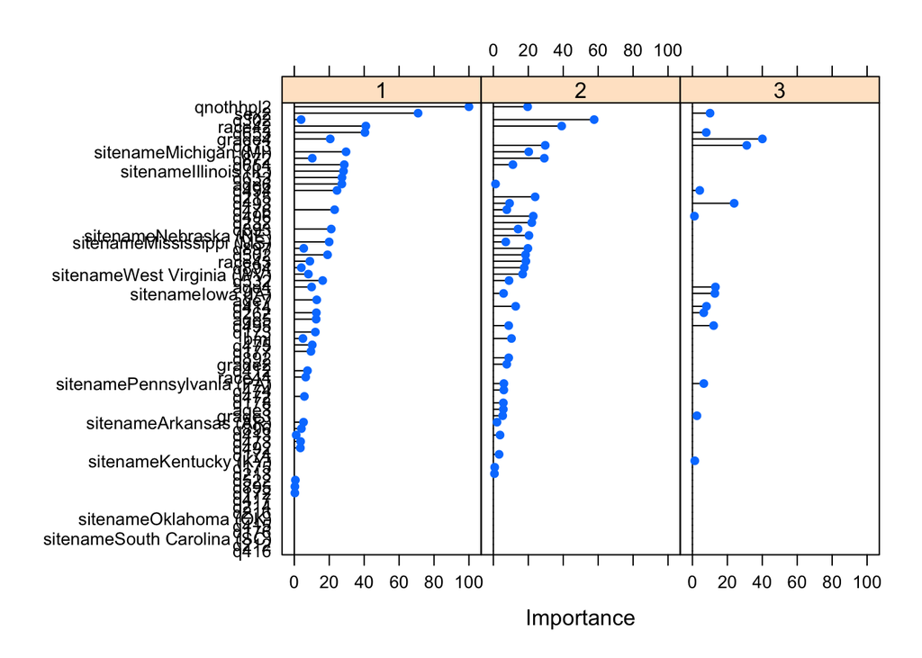

```r
plot(varImp(model_elastic_net))
```

```r
confusionMatrix(model_elastic_net)
```

```
## Cross-Validated (10 fold) Confusion Matrix
##
## (entries are percentual average cell counts across resamples)
##
##           Reference
## Prediction    1    2    3
##          1  1.3  1.1  0.2
##          2 19.0 73.1  5.4
##          3  0.0  0.0  0.0
##
##  Accuracy (average) : 0.7442
```

```r
elastic_net_outcome <- predict(model_elastic_net, df_state_train, type = "raw")
confusionMatrix(elastic_net_outcome, df_state_train$q85)
```

```
## Confusion Matrix and Statistics
##
##           Reference
## Prediction    1    2    3
##          1   57   28    5
##          2  713 2794  207
##          3    0    0    0
##
## Overall Statistics
##
##                Accuracy : 0.7495
##                  95% CI : (0.7354, 0.7632)
##     No Information Rate : 0.7419
##     P-Value [Acc > NIR] : 0.1454
##
##                   Kappa : 0.0753
##
##  Mcnemar's Test P-Value : <2e-16
##
## Statistics by Class:
##
##                      Class: 1 Class: 2 Class: 3
## Sensitivity           0.07403  0.99008  0.00000
## Specificity           0.98912  0.06314  1.00000
## Pos Pred Value        0.63333  0.75229      NaN
## Neg Pred Value        0.80802  0.68889  0.94427
## Prevalence            0.20242  0.74185  0.05573
## Detection Rate        0.01498  0.73449  0.00000
## Detection Prevalence  0.02366  0.97634  0.00000
## Balanced Accuracy     0.53157  0.52661  0.50000
```

## fit the classfication Tree model

```r
set.seed(123)

#Using 10-fold cross-validation to train model
train_control_tree <- trainControl(method = "cv", number = 10, sampling = "up")

#Create sequence of cp parameters to try
grid_tree <- expand.grid(cp = seq(0.001, 0.3, by = 0.01))

#Using rpart method to generate regression tree, using all variables in dataset to predict life expectancy
model_tree <- train(q85 ~ . ,
                     data = df_state_train,
                     method = "rpart",
                     trControl = train_control_tree,
                     tuneGrid = grid_tree)

model_tree$bestTune
```

```
##      cp
## 1 0.001
```

```r
model_tree$results
```

```
##       cp  Accuracy       Kappa   AccuracySD    KappaSD
## 1  0.001 0.4800235 0.077520345 0.0145227162 0.03283107
## 2  0.011 0.3064809 0.055958848 0.0729087004 0.02257248
## 3  0.021 0.3383782 0.052491861 0.1101736971 0.01974220
## 4  0.031 0.2024776 0.031989930 0.1371137166 0.01308733
## 5  0.041 0.1914249 0.032925196 0.1380161792 0.01231513
## 6  0.051 0.1914249 0.032925196 0.1380161792 0.01231513
## 7  0.061 0.1914249 0.032925196 0.1380161792 0.01231513
## 8  0.071 0.1914249 0.032925196 0.1380161792 0.01231513
## 9  0.081 0.1914249 0.032925196 0.1380161792 0.01231513
## 10 0.091 0.1964249 0.027551979 0.1373587587 0.01385395
## 11 0.101 0.1664249 0.020941701 0.0283804850 0.01652217
## 12 0.111 0.1976944 0.001772675 0.0150541043 0.00560569
## 13 0.121 0.2024188 0.000000000 0.0002746417 0.00000000
## 14 0.131 0.2024188 0.000000000 0.0002746417 0.00000000
```

[output cut: 16 more lines]

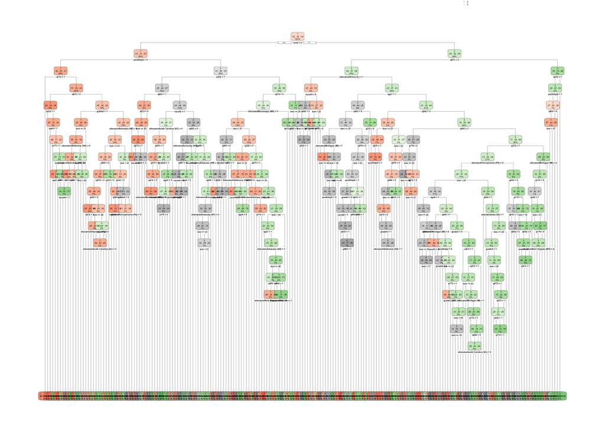

```r
#Can use rpart.plot function to visualize tree
rpart.plot(model_tree$finalModel)
```

```r
#Note you can obtain variable importance on the final model within training data
varImp(model_tree)
```

```
## rpart variable importance
##
##   only 20 most important variables shown (out of 81)
##
##           Overall
## bmi        100.00
## grade4      32.14
## qnothhpl2   21.18
## q633        21.12
## age5        20.38
## q302        19.79
## q892        16.82
## q893        16.74
## q262        16.52
## q493        15.88
## race42      15.00
## q172        14.75
## q653        14.41
## q412        14.07
## grade3      13.62
## age6        13.29
## q212        12.98
## q472        12.51
## q232        12.51
## race44      12.20
```

```r
tree_outcome <- predict(model_tree, df_state_train, type = "raw")
confusionMatrix(tree_outcome, df_state_train$q85)
```

```
## Confusion Matrix and Statistics
##
##           Reference
## Prediction    1    2    3
##          1  574  778    7
##          2  124 1588    2
##          3   72  456  203
##
## Overall Statistics
##
##                Accuracy : 0.6217
##                  95% CI : (0.6061, 0.6372)
##     No Information Rate : 0.7419
##     P-Value [Acc > NIR] : 1
##
##                   Kappa : 0.3508
##
##  Mcnemar's Test P-Value : <2e-16
##
## Statistics by Class:
##
##                      Class: 1 Class: 2 Class: 3
## Sensitivity            0.7455   0.5627  0.95755
## Specificity            0.7413   0.8717  0.85301
## Pos Pred Value         0.4224   0.9265  0.27770
## Neg Pred Value         0.9198   0.4096  0.99707
## Prevalence             0.2024   0.7419  0.05573
## Detection Rate         0.1509   0.4175  0.05336
## Detection Prevalence   0.3573   0.4506  0.19217
## Balanced Accuracy      0.7434   0.7172  0.90528
```

# Step 4, evaluation and best model selection - multinominal logistic regression, random forest, SVM, classfication Tree, Elastic Net, ridge, lasso regression, and classification tree

```r
# model multinominal logistic regression
multinom_outcome <- predict(model_multinom, df_state_train, type = "raw")
multinom_evaluation <- confusionMatrix(multinom_outcome, df_state_train$q85, positive = "1")
multinom_evaluation
```

```
## Confusion Matrix and Statistics
##
##           Reference
## Prediction    1    2    3
##          1  424  715   48
##          2  194 1359   53
##          3  152  748  111
##
## Overall Statistics
##
##                Accuracy : 0.4979
##                  95% CI : (0.4819, 0.5139)
##     No Information Rate : 0.7419
##     P-Value [Acc > NIR] : 1
##
##                   Kappa : 0.1753
##
##  Mcnemar's Test P-Value : <2e-16
##
## Statistics by Class:
##
##                      Class: 1 Class: 2 Class: 3
## Sensitivity            0.5506   0.4816  0.52358
## Specificity            0.7485   0.7485  0.74944
## Pos Pred Value         0.3572   0.8462  0.10979
## Neg Pred Value         0.8678   0.3344  0.96384
## Prevalence             0.2024   0.7419  0.05573
## Detection Rate         0.1115   0.3573  0.02918
## Detection Prevalence   0.3120   0.4222  0.26577
## Balanced Accuracy      0.6496   0.6150  0.63651
```

```r
# model random forest
rf_outcome <- predict(model_rf, df_state_train, type = "raw")
rf_evaluation <- confusionMatrix(rf_outcome, df_state_train$q85, positive = "1")
rf_evaluation
```

```
## Confusion Matrix and Statistics
##
##           Reference
## Prediction    1    2    3
##          1  770    1    0
##          2    0 2820    0
##          3    0    1  212
##
## Overall Statistics
##
##                Accuracy : 0.9995
##                  95% CI : (0.9981, 0.9999)
##     No Information Rate : 0.7419
##     P-Value [Acc > NIR] : < 2.2e-16
##
##                   Kappa : 0.9987
##
##  Mcnemar's Test P-Value : NA
##
## Statistics by Class:
##
##                      Class: 1 Class: 2 Class: 3
## Sensitivity            1.0000   0.9993  1.00000
## Specificity            0.9997   1.0000  0.99972
## Pos Pred Value         0.9987   1.0000  0.99531
## Neg Pred Value         1.0000   0.9980  1.00000
## Prevalence             0.2024   0.7419  0.05573
## Detection Rate         0.2024   0.7413  0.05573
## Detection Prevalence   0.2027   0.7413  0.05599
## Balanced Accuracy      0.9998   0.9996  0.99986
```

```r
# model SVM
svm_outcome <- predict(model_svc, df_state_train, type = "raw")
svm_evaluation <- confusionMatrix(svm_outcome, df_state_train$q85, positive = "1")
svm_evaluation
```

```
## Confusion Matrix and Statistics
##
##           Reference
## Prediction    1    2    3
##          1  436  742   51
##          2  175 1286   46
##          3  159  794  115
##
## Overall Statistics
##
##                Accuracy : 0.4829
##                  95% CI : (0.4669, 0.4989)
##     No Information Rate : 0.7419
##     P-Value [Acc > NIR] : 1
##
##                   Kappa : 0.1727
##
##  Mcnemar's Test P-Value : <2e-16
##
## Statistics by Class:
##
##                      Class: 1 Class: 2 Class: 3
## Sensitivity            0.5662   0.4557  0.54245
## Specificity            0.7386   0.7749  0.73469
## Pos Pred Value         0.3548   0.8534  0.10768
## Neg Pred Value         0.8703   0.3313  0.96455
## Prevalence             0.2024   0.7419  0.05573
## Detection Rate         0.1146   0.3381  0.03023
## Detection Prevalence   0.3231   0.3962  0.28076
## Balanced Accuracy      0.6524   0.6153  0.63857
```

```r
# model lasso
lasso_outcome <- predict(model_lasso, df_state_train, type = "raw")
lasso_evaluation <- confusionMatrix(lasso_outcome, df_state_train$q85, positive = "1")
lasso_evaluation
```

```
## Confusion Matrix and Statistics
##
##           Reference
## Prediction    1    2    3
##          1   67   40    5
##          2  703 2782  207
##          3    0    0    0
##
## Overall Statistics
##
##                Accuracy : 0.7489
##                  95% CI : (0.7348, 0.7627)
##     No Information Rate : 0.7419
##     P-Value [Acc > NIR] : 0.1631
##
##                   Kappa : 0.0839
##
##  Mcnemar's Test P-Value : <2e-16
##
## Statistics by Class:
##
##                      Class: 1 Class: 2 Class: 3
## Sensitivity           0.08701  0.98583  0.00000
## Specificity           0.98517  0.07332  1.00000
## Pos Pred Value        0.59821  0.75352      NaN
## Neg Pred Value        0.80959  0.64286  0.94427
## Prevalence            0.20242  0.74185  0.05573
## Detection Rate        0.01761  0.73134  0.00000
## Detection Prevalence  0.02944  0.97056  0.00000
## Balanced Accuracy     0.53609  0.52957  0.50000
```

```r
# model ridge
ridge_outcome <- predict(model_ridge, df_state_train, type = "raw")
ridge_evaluation <- confusionMatrix(ridge_outcome, df_state_train$q85, positive = "1")
ridge_evaluation
```

```
## Confusion Matrix and Statistics
##
##           Reference
## Prediction    1    2    3
##          1   75   40    5
##          2  695 2782  207
##          3    0    0    0
##
## Overall Statistics
##
##                Accuracy : 0.7511
##                  95% CI : (0.737, 0.7647)
##     No Information Rate : 0.7419
##     P-Value [Acc > NIR] : 0.1002
##
##                   Kappa : 0.0953
##
##  Mcnemar's Test P-Value : <2e-16
##
## Statistics by Class:
##
##                      Class: 1 Class: 2 Class: 3
## Sensitivity           0.09740  0.98583  0.00000
## Specificity           0.98517  0.08147  1.00000
## Pos Pred Value        0.62500  0.75516      NaN
## Neg Pred Value        0.81135  0.66667  0.94427
## Prevalence            0.20242  0.74185  0.05573
## Detection Rate        0.01972  0.73134  0.00000
## Detection Prevalence  0.03155  0.96845  0.00000
## Balanced Accuracy     0.54129  0.53365  0.50000
```

```r
# model elastic net
elastic_net_outcome <- predict(model_elastic_net, df_state_train, type = "raw")
elastic_net_evaluation <- confusionMatrix(elastic_net_outcome, df_state_train$q85, positive = "1")
elastic_net_evaluation
```

```
## Confusion Matrix and Statistics
##
##           Reference
## Prediction    1    2    3
##          1   57   28    5
##          2  713 2794  207
##          3    0    0    0
##
## Overall Statistics
##
##                Accuracy : 0.7495
##                  95% CI : (0.7354, 0.7632)
##     No Information Rate : 0.7419
##     P-Value [Acc > NIR] : 0.1454
##
##                   Kappa : 0.0753
##
##  Mcnemar's Test P-Value : <2e-16
##
## Statistics by Class:
##
##                      Class: 1 Class: 2 Class: 3
## Sensitivity           0.07403  0.99008  0.00000
## Specificity           0.98912  0.06314  1.00000
## Pos Pred Value        0.63333  0.75229      NaN
## Neg Pred Value        0.80802  0.68889  0.94427
## Prevalence            0.20242  0.74185  0.05573
## Detection Rate        0.01498  0.73449  0.00000
## Detection Prevalence  0.02366  0.97634  0.00000
## Balanced Accuracy     0.53157  0.52661  0.50000
```

```r
# model classification tree
tree_outcome <- predict(model_tree, df_state_train, type = "raw")
tree_evaluation <- confusionMatrix(tree_outcome, df_state_train$q85, positive = "1")
tree_evaluation
```

```
## Confusion Matrix and Statistics
##
##           Reference
## Prediction    1    2    3
##          1  574  778    7
##          2  124 1588    2
##          3   72  456  203
##
## Overall Statistics
##
##                Accuracy : 0.6217
##                  95% CI : (0.6061, 0.6372)
##     No Information Rate : 0.7419
##     P-Value [Acc > NIR] : 1
##
##                   Kappa : 0.3508
##
##  Mcnemar's Test P-Value : <2e-16
##
## Statistics by Class:
##
##                      Class: 1 Class: 2 Class: 3
## Sensitivity            0.7455   0.5627  0.95755
## Specificity            0.7413   0.8717  0.85301
## Pos Pred Value         0.4224   0.9265  0.27770
## Neg Pred Value         0.9198   0.4096  0.99707
## Prevalence             0.2024   0.7419  0.05573
## Detection Rate         0.1509   0.4175  0.05336
## Detection Prevalence   0.3573   0.4506  0.19217
## Balanced Accuracy      0.7434   0.7172  0.90528
```

```r
# Accuracy and 95% CI plot
compare_resamp <- resamples(list(
  multinom = model_multinom,
  random_forest = model_rf,
  SVM = model_svc,
  lasso = model_lasso,
  ridge = model_ridge,
  elastic_net = model_elastic_net,
  cla_tree = model_tree
))

summary(compare_resamp)
```

```
##
## Call:
## summary.resamples(object = compare_resamp)
##
## Models: multinom, random_forest, SVM, lasso, ridge, elastic_net, cla_tree
## Number of resamples: 10
##
## Accuracy
##                    Min.   1st Qu.    Median      Mean   3rd Qu.      Max. NA's
## multinom      0.4356955 0.4504300 0.4671053 0.4689985 0.4871840 0.5131579    0
## random_forest 0.6973684 0.7163541 0.7279907 0.7218739 0.7289474 0.7375328    0
## SVM           0.4041995 0.4471457 0.4586131 0.4595462 0.4789474 0.5078947    0
## lasso         0.7296588 0.7370148 0.7447368 0.7436932 0.7495079 0.7578947    0
## ridge         0.7296588 0.7380180 0.7463842 0.7447465 0.7495079 0.7605263    0
## elastic_net   0.7322835 0.7401316 0.7460526 0.7442195 0.7478657 0.7552632    0
## cla_tree      0.4514436 0.4720990 0.4815789 0.4800235 0.4852259 0.5039370    0
##
## Kappa
##                      Min.    1st Qu.     Median       Mean    3rd Qu.      Max.
## multinom      0.092656181 0.11361188 0.11972405 0.13012293 0.13850711 0.1995810
## random_forest 0.022261998 0.11802790 0.14748271 0.13290085 0.15932118 0.1867053
## SVM           0.084173408 0.11123791 0.12791936 0.12931404 0.14757190 0.1746103
## lasso         0.009115241 0.05692196 0.05969377 0.06417125 0.08162945 0.1193955
## ridge         0.009115241 0.05746306 0.08309820 0.07471151 0.08877889 0.1334419
## elastic_net   0.008420086 0.04808452 0.05692542 0.05819111 0.08043327 0.1052032
## cla_tree      0.015582879 0.06435858 0.08204689 0.07752034 0.10584091 0.1118266
##               NA's
## multinom         0
## random_forest    0
## SVM              0
## lasso            0
## ridge            0
## elastic_net      0
## cla_tree         0
```

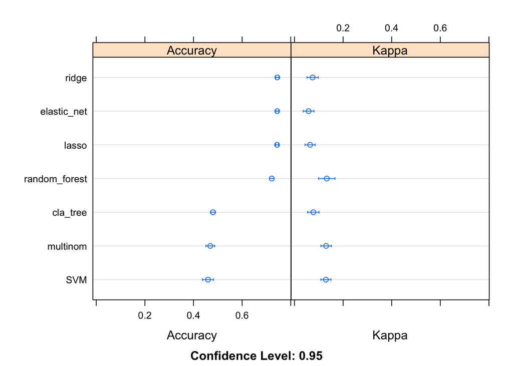

```r
dotplot(compare_resamp)
```

```r
# create table of accuracy and kappa
postResample(multinom_outcome, df_state_train$q85)
```

```
##  Accuracy     Kappa
## 0.4978970 0.1752927
```

```r
postResample(rf_outcome, df_state_train$q85)
```

```
##  Accuracy     Kappa
## 0.9994742 0.9987047
```

```r
postResample(svm_outcome, df_state_train$q85)
```

```
##  Accuracy     Kappa
## 0.4829127 0.1727432
```

```r
postResample(lasso_outcome, df_state_train$q85)
```

```
##   Accuracy      Kappa
## 0.74894848 0.08385939
```

```r
postResample(ridge_outcome, df_state_train$q85)
```

```
##   Accuracy      Kappa
## 0.75105152 0.09527928
```

```r
postResample(elastic_net_outcome, df_state_train$q85)
```

```
##   Accuracy      Kappa
## 0.74947424 0.07525009
```

```r
postResample(tree_outcome, df_state_train$q85)
```

```
##  Accuracy     Kappa
## 0.6217140 0.3508198
```